# INFO370 PS2

*Name*: Bridget Leonard \ *Collaborators*: 1) Saimanasvi Charugundla

```python
import numpy as np
import pandas as pd
import seaborn as sns
```

# Q.1 Cleaning Data

1.1

```python
gm = pd.read_csv("../data/gapminder.csv.bz2", sep="\t")
```

1.2

```python
gm.shape
```

```
(13055, 25)
```

```python
gm.head(5)
```

|  | iso3 | name | iso2 | region | sub-region | intermediate-region | time | totalPopulation | fertilityRate | lifeExpectancy | ... | accessElectricity | agriculturalLand | agricultureTractors | cerealProduction | fertilizerHa | co2 | greenhouseGases | co2_PC | pm2.5_35 | battleDeaths |
| --- | --- | --- | --- | --- | --- | --- | --- | --- | --- | --- | --- | --- | --- | --- | --- | --- | --- | --- | --- | --- | --- |
| 0 | ABW | Aruba | AW | Americas | Latin America and the Caribbean | Caribbean | 1960.0 | 54211.0 | 4.820 | 65.662 | ... | NaN | NaN | NaN | NaN | NaN | 11092.675 | NaN | 204.62037 | NaN | NaN |
| 1 | ABW | Aruba | AW | Americas | Latin America and the Caribbean | Caribbean | 1961.0 | 55438.0 | 4.655 | 66.074 | ... | NaN | 20.0 | NaN | NaN | NaN | 11576.719 | NaN | 208.82281 | NaN | NaN |
| 2 | ABW | Aruba | AW | Americas | Latin America and the Caribbean | Caribbean | 1962.0 | 56225.0 | 4.471 | 66.444 | ... | NaN | 20.0 | NaN | NaN | NaN | 12713.489 | NaN | 226.11808 | NaN | NaN |
| 3 | ABW | Aruba | AW | Americas | Latin America and the Caribbean | Caribbean | 1963.0 | 56695.0 | 4.271 | 66.787 | ... | NaN | 20.0 | NaN | NaN | NaN | 12178.107 | NaN | 214.80037 | NaN | NaN |
| 4 | ABW | Aruba | AW | Americas | Latin America and the Caribbean | Caribbean | 1964.0 | 57032.0 | 4.059 | 67.113 | ... | NaN | 20.0 | NaN | NaN | NaN | 11840.743 | NaN | 207.61578 | NaN | NaN |

5 rows × 25 columns

The data set has 13055 rows and 25 columns. The first few lines contain proper variable/column names and reasonable values.

1.3

```python
gm.isna().sum()
```

```
iso3                       0
name                     240
iso2                     300
region                   241
sub-region               241
intermediate-region     7697
time                      36
totalPopulation           76
fertilityRate           1307
lifeExpectancy          1325
childMortality          2600
youthFemaleLiteracy    12134
youthMaleLiteracy      12134
adultLiteracy          12118
GDP_PC                  3585
accessElectricity       7608
agriculturalLand        1910
agricultureTractors     6947
cerealProduction        3606
fertilizerHa            4929
co2                     2658
greenhouseGases         4994
co2_PC                  2661
pm2.5_35               10727
battleDeaths           12051
dtype: int64
```

Variables like name, time, region, totalPopulation are good variables with few missing values. The three literacy variables as well as pm2.5_35 and battleDeaths contain a lot of missing values and are therefore almost unusable.

1.4

```python
naTime = gm[gm.time.isna()]
naTime[["name","iso2","totalPopulation"]]
```

|  | name | iso2 | totalPopulation |
| --- | --- | --- | --- |
| 180 | Anguilla | AI | NaN |
| 181 | Åland Islands | AX | NaN |
| 542 | Antarctica | AQ | NaN |
| 543 | French Southern Territories | TF | NaN |
| 964 | Bonaire, Sint Eustatius and Saba | BQ | NaN |
| 1325 | Saint Barthélemy | BL | NaN |
| 1806 | Bouvet Island | BV | NaN |
| 1987 | Cocos (Keeling) Islands | CC | NaN |
| 2468 | Cook Islands | CK | NaN |
| 2769 | Curaçao | CW | NaN |
| 2770 | Christmas Island | CX | NaN |
| 3491 | Western Sahara | EH | NaN |
| 3792 | Falkland Islands (Malvinas) | FK | NaN |
| 4213 | Guernsey | GG | NaN |
| 4394 | Guadeloupe | GP | NaN |
| 4815 | French Guiana | GF | NaN |
| 4996 | Heard Island and McDonald Islands | HM | NaN |
| 5297 | Isle of Man | IM | NaN |
| 5358 | British Indian Ocean Territory | IO | NaN |
| 5779 | Jersey | JE | NaN |
| 8180 | Montserrat | MS | NaN |
| 8181 | Martinique | MQ | NaN |
| 8362 | Mayotte | YT | NaN |
| 8543 | Norfolk Island | NF | NaN |
| 8664 | Niue | NU | NaN |
| 9205 | Pitcairn | PN | NaN |
| 9925 | Réunion | RE | NaN |
| 10346 | South Georgia and the South Sandwich Islands | GS | NaN |
| 10347 | Saint Helena, Ascension and Tristan da Cunha | SH | NaN |
| 10348 | Svalbard and Jan Mayen | SJ | NaN |
| 10649 | Saint Pierre and Miquelon | PM | NaN |
| 11610 | Tokelau | TK | NaN |
| 12031 | Taiwan, Province of China | TW | NaN |
| 12212 | United States Minor Outlying Islands | UM | NaN |
| 12393 | Holy See | VA | NaN |
| 12754 | Wallis and Futuna | WF | NaN |

1.5

There is likely no census data collected by these countries/territories so there's lots of missing values in these rows including time.

1.6

```python
iso2drop = gm.dropna(subset=["iso2"])
iso2drop.shape
```

```
(12755, 25)
```

```python
iso2drop.name.isna().sum()
```

```
0
```

There are 0 rows where the name is missing but iso-2 code is there.

```python
namedrop = gm.dropna(subset=["name"])
namedrop.shape
```

```
(12815, 25)
```

```python
namedrop.iso2.isna().sum()
```

```
60
```

There are 60 rows where the iso-2 code is missing but name is there.

```python
namedrop[namedrop.iso2.isna()].head(5)
```

|  | iso3 | name | iso2 | region | sub-region | intermediate-region | time | totalPopulation | fertilityRate | lifeExpectancy | ... | accessElectricity | agriculturalLand | agricultureTractors | cerealProduction | fertilizerHa | co2 | greenhouseGases | co2_PC | pm2.5_35 | battleDeaths |
| --- | --- | --- | --- | --- | --- | --- | --- | --- | --- | --- | --- | --- | --- | --- | --- | --- | --- | --- | --- | --- | --- |
| 8363 | NAM | Namibia | NaN | Africa | Sub-Saharan Africa | Southern Africa | 1960.0 | 634142.0 | 6.149 | 46.483 | ... | NaN | NaN | NaN | NaN | NaN | NaN | NaN | NaN | NaN | NaN |
| 8364 | NAM | Namibia | NaN | Africa | Sub-Saharan Africa | Southern Africa | 1961.0 | 649279.0 | 6.167 | 47.231 | ... | NaN | 386420.0 | NaN | 35592.0 | NaN | NaN | NaN | NaN | NaN | NaN |
| 8365 | NAM | Namibia | NaN | Africa | Sub-Saharan Africa | Southern Africa | 1962.0 | 665115.0 | 6.184 | 47.957 | ... | NaN | 386420.0 | NaN | 37068.0 | NaN | NaN | NaN | NaN | NaN | NaN |
| 8366 | NAM | Namibia | NaN | Africa | Sub-Saharan Africa | Southern Africa | 1963.0 | 681637.0 | 6.199 | 48.656 | ... | NaN | 386420.0 | NaN | 37208.0 | NaN | NaN | NaN | NaN | NaN | NaN |
| 8367 | NAM | Namibia | NaN | Africa | Sub-Saharan Africa | Southern Africa | 1964.0 | 698796.0 | 6.216 | 49.325 | ... | NaN | 386460.0 | NaN | 39600.0 | NaN | NaN | NaN | NaN | NaN | NaN |

5 rows × 25 columns

7.

The iso-2 code for Namibia is "NA". This likely was coded wrong in the data as a missing value (NA, NaN,etc) instead of a valid value.

8.

```python
len(gm.name.unique())
```

```
250
```

By taking the unique values of the "name" column, we get a list of unique countries. Taking the length of this array provides the number of unique countries in the dataset.

9.

```python
gm.time.min(), gm.time.max()
```

```
(1960.0, 2019.0)
```

# Q.2 Wealth

2.1

```python
gdp = gm.dropna(subset=["GDP_PC"])
gdp.shape
```

```
(9470, 25)
```

```python
gdp.time.max()
```

```
2019.0
```

The most recent year that we have GDP data is 2019.

2.2

```python
gdp[gdp.time == 2019].GDP_PC.mean()
```

```
15055.352217243239
```

The mean GDP per capita across all countries in 2019 was $15055.35

2.3

```python
maxyear = gdp.groupby("name").time.max()
maxyear.head()
```

```
name
Afghanistan       2019.0
Albania           2019.0
Algeria           2019.0
American Samoa    2018.0
Andorra           2019.0
Name: time, dtype: float64
```

```python
maxyear.min(), maxyear.max()
```

```
(2010.0, 2019.0)
```

```python
maxyear.nsmallest(5)
```

```
name
Djibouti                    2010.0
Faroe Islands               2010.0
Liechtenstein               2010.0
Turks and Caicos Islands    2010.0
Eritrea                     2011.0
Name: time, dtype: float64
```

These countries are all very small so likely don't have many changes to document with frequent censuses.

2.4

```python
reg = gdp[gdp.time == 2019].groupby("region").GDP_PC.mean().sort_values(ascending=False)
reg
```

```
region
Europe      33227.983767
Americas    14516.826303
Asia        14116.124163
Oceania     11817.735554
Africa       2765.708956
Name: GDP_PC, dtype: float64
```

This order seems reasonable for mean GDP per capita for each country. Europe contains smaller countries that have high GDP per capita despite lower relative GDP to other larger countries.

# Q3.Descriptive Stats

3.1

```python
gdp60 = gdp[gdp.time == 1960]
gdp60.shape
```

```
(91, 25)
```

```python
gdp60.GDP_PC.min(), gdp60.GDP_PC.max()
```

```
(153.34393, 33362.70762)
```

```python
gdp60.GDP_PC.median()
```

```
1751.86291
```

```python
gdp60.GDP_PC.mean()
```

```
5050.295039780219
```

```python
gdp19 = gdp[gdp.time == 2019]
gdp19.shape
```

```
(185, 25)
```

```python
gdp19.GDP_PC.min(), gdp19.GDP_PC.max()
```

```
(208.07473, 111043.5317)
```

```python
gdp19.GDP_PC.median()
```

```
5922.52759
```

```python
gdp19.GDP_PC.mean()
```

```
15055.352217243239
```

3.2

The first thing I noticed was how the minimum GDP per capita has changed very little (50) since 1960 to 2019 but the maximum has changed a lot (77600). It seems that while some countries have the same wealth, others have increased their wealth by a lot, demonstrating more world wealth inequality. Additionally, the mean GDP per capita in 2019 is not only much larger than the median, communicating a right skewed distribution (i.e., few very rich countries) but the ratio between the two values has increased a lot since 1960. All of this simple statistics suggest that majority of countries have maintained a similar GDP per captia in 2019 to what it was in 1960 while some coutnries have had severe increases in GDP per capita, thus creating more world wealth inequality.

3.3

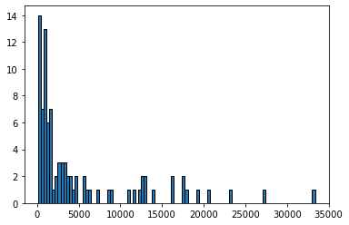

```python
_ = plt.hist(gdp60.GDP_PC, bins=100, edgecolor="black")
```

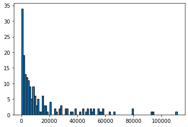

```python
_ = plt.hist(gdp19.GDP_PC, bins=100, edgecolor="black")
```

Although the distributions have a very similar shape (right-skewed), it is interesting to see the differences between the x-axis range. The 2019 distribution has a GDP_PC range that's almost three times as large as 1960. This means that while there was still world wealth inequality in 1960, it is exacerbated in 2019 with outliers of almost three times the wealth as in 1960.

3.5

```python
pct80_60 = np.percentile(gdp60.GDP_PC, 80)
pct80_60
```

```
8789.01931
```

```python
pct20_60 = np.percentile(gdp60.GDP_PC, 20)
pct20_60
```

```
690.36877
```

```python
s80_60 = np.sum(gdp60.GDP_PC[gdp60.GDP_PC > pct80_60])
s80_60
```

```
309637.59462
```

```python
s20_60 = np.sum(gdp60.GDP_PC[gdp60.GDP_PC < pct20_60])
s20_60
```

```
6391.13716
```

```python
qsr60 = s80_60/s20_60
qsr60
```

```
48.44796581082919
```

The quintile shared ratio for GDP per capita in 1960 was 48.448. This means the ratio of the total wealth owned by the wealthiest 20% to the total wealth owned by the poorest 20% is 48.448.

```python
pct80_19 = np.percentile(gdp19.GDP_PC, 80)
pct80_19
```

```
25178.698958000048
```

```python
pct20_19 = np.percentile(gdp19.GDP_PC, 20)
pct20_19
```

```
1571.2396540000002
```

```python
s80_19 = np.sum(gdp19.GDP_PC[gdp19.GDP_PC > pct80_19])
s80_19
```

```
1868384.4504999998
```

```python
s20_19 = np.sum(gdp19.GDP_PC[gdp19.GDP_PC < pct20_19])
s20_19
```

```
32649.716679999998
```

```python
qsr19 = s80_19/s20_19
qsr19
```

```
57.22513517688509
```

The quintile shared ratio for GDP per capita in 2019 was 57.225. This means the ratio of the total wealth owned by the wealthiest 20% to the total wealth owned by the poorest 20% is 57.225.

These two QSRs show us that inequality has grown over time. Since the 2019 QSR is larger than the 1960 QSR, the top 20% wealthiest countries now own even more wealth compared to the poorest 20%.

3.7

```python
total = sum(gdp60.GDP_PC)
for pct in range(99, 50, -1):
    threshold = np.percentile(gdp60.GDP_PC, pct)
    share = gdp60.GDP_PC[gdp60.GDP_PC > threshold].sum()/total
    if 100*share > pct:
        print(pct, share)
        break
```

```
75 0.7539576669722629
```

In 1960, the top 25% of wealthiest countries owned 75% of total world wealth.

```python
total = sum(gdp19.GDP_PC)
for pct in range(99, 50, -1):
    threshold = np.percentile(gdp19.GDP_PC, pct)
    share = gdp19.GDP_PC[gdp19.GDP_PC > threshold].sum()/total
    if 100*share > pct:
        print(pct, share)
        break
```

```
74 0.752332321539216
```

The pareto ratio has stayed roughly the same from 1960 to 2019. This means we have a different conclusion than the what we made off of the QSR values. That is, based on the pareto ratios, world wealth inequality has not increased over the past years.

3.8

I think these values are somewhat helpful in communicating how world inequality has changed in the past 60 years. Beyond the faults that come from using GDP per capita as our main measure of wealth, I think the pareto ratio can fail to capture distributions that are "evenly" right skewed. By even, I mean that there values are pretty consistent in frequency in the middle of the range before really extreme outliers exist at the end. These high values likely fall below the 80th percentile and help "boost" the wealth owned by the lower 80%. I think the data overall can provide an objective measure that simply shows that wealth inequality has increased over time. I especially think the histograms are a powerful visual in communicating disparities and change over time. Nevertheless, world inequality expands beyond GDP per capita to include different measures of quality of life like infant mortality, life span, hunger statistics, physical safety, and much more.

# Q4.Health

4.1

```python
gm[gm.time == 1960].childMortality.isna().sum()
```

```
104
```

```python
gm[gm.time == 2019].childMortality.isna().sum()
```

```
24
```

Only 24 countries are missing child mortality data in 2019 compared to 104 missing values in 1960. This data is improving over time and becoming more documented/accessible.

4.2

```python
gm.childMortality.min(), gm.childMortality.max()
```

```
(1.7, 420.6)
```

```python
gm.nlargest(3, "childMortality")
```

|  | iso3 | name | iso2 | region | sub-region | intermediate-region | time | totalPopulation | fertilityRate | lifeExpectancy | ... | accessElectricity | agriculturalLand | agricultureTractors | cerealProduction | fertilizerHa | co2 | greenhouseGases | co2_PC | pm2.5_35 | battleDeaths |
| --- | --- | --- | --- | --- | --- | --- | --- | --- | --- | --- | --- | --- | --- | --- | --- | --- | --- | --- | --- | --- | --- |
| 7703 | MLI | Mali | ML | Africa | Sub-Saharan Africa | Western Africa | 1963.0 | 5441613.0 | 7.011 | 28.782 | ... | NaN | 317080.0 | 150.0 | 1058200.0 | 0.21238 | 176.016 | NaN | 0.03235 | NaN | NaN |
| 7704 | MLI | Mali | ML | Africa | Sub-Saharan Africa | Western Africa | 1964.0 | 5503752.0 | 7.030 | 29.097 | ... | NaN | 317130.0 | 200.0 | 947700.0 | 0.18149 | 176.016 | NaN | 0.03198 | NaN | NaN |
| 12817 | YEM | Yemen | YE | Asia | Western Asia | NaN | 1962.0 | 5473671.0 | 7.991 | 30.500 | ... | NaN | 233480.0 | 440.0 | 963100.0 | NaN | 69.673 | NaN | 0.01273 | NaN | NaN |

3 rows × 25 columns

```python
maxCM = gm.childMortality.idxmax()
gm.iloc[[maxCM]]
```

|  | iso3 | name | iso2 | region | sub-region | intermediate-region | time | totalPopulation | fertilityRate | lifeExpectancy | ... | accessElectricity | agriculturalLand | agricultureTractors | cerealProduction | fertilizerHa | co2 | greenhouseGases | co2_PC | pm2.5_35 | battleDeaths |
| --- | --- | --- | --- | --- | --- | --- | --- | --- | --- | --- | --- | --- | --- | --- | --- | --- | --- | --- | --- | --- | --- |
| 7703 | MLI | Mali | ML | Africa | Sub-Saharan Africa | Western Africa | 1963.0 | 5441613.0 | 7.011 | 28.782 | ... | NaN | 317080.0 | 150.0 | 1058200.0 | 0.21238 | 176.016 | NaN | 0.03235 | NaN | NaN |

1 rows × 25 columns

```python
gm.nsmallest(3, "childMortality")
```

|  | iso3 | name | iso2 | region | sub-region | intermediate-region | time | totalPopulation | fertilityRate | lifeExpectancy | ... | accessElectricity | agriculturalLand | agricultureTractors | cerealProduction | fertilizerHa | co2 | greenhouseGases | co2_PC | pm2.5_35 | battleDeaths |
| --- | --- | --- | --- | --- | --- | --- | --- | --- | --- | --- | --- | --- | --- | --- | --- | --- | --- | --- | --- | --- | --- |
| 10587 | SMR | San Marino | SM | Europe | Southern Europe | NaN | 2018.0 | 33785.0 | NaN | NaN | ... | 100.0 | 23.0 | NaN | NaN | NaN | NaN | NaN | NaN | NaN | NaN |
| 10588 | SMR | San Marino | SM | Europe | Southern Europe | NaN | 2019.0 | 33860.0 | NaN | NaN | ... | 100.0 | NaN | NaN | NaN | NaN | NaN | NaN | NaN | NaN | NaN |
| 10586 | SMR | San Marino | SM | Europe | Southern Europe | NaN | 2017.0 | 33671.0 | NaN | NaN | ... | 100.0 | 23.0 | NaN | NaN | NaN | NaN | NaN | NaN | NaN | NaN |

3 rows × 25 columns

```python
minCM = gm.childMortality.idxmin()
gm.iloc[[minCM]]
```

|  | iso3 | name | iso2 | region | sub-region | intermediate-region | time | totalPopulation | fertilityRate | lifeExpectancy | ... | accessElectricity | agriculturalLand | agricultureTractors | cerealProduction | fertilizerHa | co2 | greenhouseGases | co2_PC | pm2.5_35 | battleDeaths |
| --- | --- | --- | --- | --- | --- | --- | --- | --- | --- | --- | --- | --- | --- | --- | --- | --- | --- | --- | --- | --- | --- |
| 10587 | SMR | San Marino | SM | Europe | Southern Europe | NaN | 2018.0 | 33785.0 | NaN | NaN | ... | 100.0 | 23.0 | NaN | NaN | NaN | NaN | NaN | NaN | NaN | NaN |

1 rows × 25 columns

The miminum child mortality in the data frame is 1.7 and the maximum is 420.6. The three largest child mortality values correspond to Mali (1963 and 1964) and Yemen (1962). The three smallest child mortality values correspond to San Marino (2017-2019).

4.3

```python
regCMmax = gm[gm.time == 2019].groupby("region").childMortality.idxmax()
regCMmax
```

```
region
Africa      8603
Americas    5176
Asia        9144
Europe      7399
Oceania     6199
Name: childMortality, dtype: int64
```

```python
for index in regCMmax:
    print(gm.iloc[[index]].name)
```

```
8603    Nigeria
Name: name, dtype: object
5176    Haiti
Name: name, dtype: object
9144    Pakistan
Name: name, dtype: object
7399    Moldova, Republic of
Name: name, dtype: object
6199    Kiribati
Name: name, dtype: object
```

```python
regCMmin = gm[gm.time == 2019].groupby("region").childMortality.idxmin()
regCMmin
```

```
region
Africa       6679
Americas     1986
Asia         2890
Europe      10588
Oceania       663
Name: childMortality, dtype: int64
```

```python
for index in regCMmin:
    print(gm.iloc[[index]].name)
```

```
6679    Libya
Name: name, dtype: object
1986    Canada
Name: name, dtype: object
2890    Cyprus
Name: name, dtype: object
10588    San Marino
Name: name, dtype: object
663    Australia
Name: name, dtype: object
```

In Africa, Nigeria has the highest child mortality while Libya has the lowest. In the Americas, Haiti has the highest child mortality while Canada has the lowest. In Asia, Pakistan has the highest child mortality while Cyprus has the lowest. In Europe, Moldova has the highest child mortality while San Marino has the lowest. Lastly, in Oceania, Kiribati has the highest child mortality while Australia has the lowest. These are all values based off child mortality in 2019.

# Q5.Graphical Analysis

5.1

```python
gm.iloc[[gm[gm.time == 2019].childMortality.idxmax()]].name
```

```
8603    Nigeria
Name: name, dtype: object
```

```python
gm.iloc[[gm[gm.time == 2019].childMortality.idxmin()]].name
```

```
10588    San Marino
Name: name, dtype: object
```

```python
countryList = ["Nigeria", "San Marino", "Egypt", "Brazil", "Cambodia"]
plotData = gm[gm["name"].isin(countryList)]
plotData.shape
```

```
(300, 25)
```

```python
pData = plotData[["name", "time", "childMortality"]]
```

```python
pData
```

|  | name | time | childMortality |
| --- | --- | --- | --- |
| 1566 | Brazil | 1960.0 | 168.9 |
| 1567 | Brazil | 1961.0 | 164.1 |
| 1568 | Brazil | 1962.0 | 159.7 |
| 1569 | Brazil | 1963.0 | 155.5 |
| 1570 | Brazil | 1964.0 | 151.7 |
| ... | ... | ... | ... |
| 10584 | San Marino | 2015.0 | 2.0 |
| 10585 | San Marino | 2016.0 | 1.9 |
| 10586 | San Marino | 2017.0 | 1.8 |
| 10587 | San Marino | 2018.0 | 1.7 |
| 10588 | San Marino | 2019.0 | 1.7 |

300 rows × 3 columns

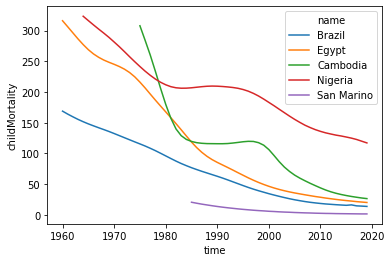

```python
_ = sns.lineplot(x = "time", y = "childMortality", data=pData, hue="name")
```

# Time Spent

I spent about 7 hours on this problem set.